# Time Series with R: Simplified Version

Example with NY Birth Data

Ranadeep Daw

2024-11-07

## Resources

- A greate resource can be found at **A Little Book of R For Time Series** by Avril Coghlan. [Here](https://readthedocs.org/projects/a-little-book-of-r-for-time-series/downloads/pdf/latest/) is the publicly available resource.
- For data, we will use Rob Hyndman’s Time Series Data Library, availble [here](http://robjhyndman.com/TSDL/).

## $\texttt{R}$ Libraries

- We will use the $\texttt{ggplot2}$, $\texttt{forecast}$, and $\texttt{tseries}$ libraries. If you don’t have the library, you must install them each one at a time beforehand using $\texttt{install.packages(...)}$ command.

```r
library("forecast")
library("tseries")
library("ggplot2")
```

## Data

- We will use the nybirths data, available at the following link: http://robjhyndman.com/tsdldata/data/nybirths.dat.
- The dataset is on the number of births per month in New York city, between January 1949 to December 1959.

## Step 1: Load the data in $\texttt{R}$

- Usually I give you this step in homeworks and exams.
- In future, if you do not know how to load a data, you can replicate the $\texttt{scan}$ code as below to read text files.
- Sometimes you have seen examples of $\texttt{read.table}$ or $\texttt{read.csv}$, that specifically reads the csv files.

```r
nybirths <- scan("http://robjhyndman.com/tsdldata/data/nybirths.dat", skip = 36)
```

- The above code loads the data in a dataframe called $\texttt{nybirths}$ in $\texttt{R}$. Look at the data:

```r
nybirths
```

```
##   [1] 21.548 20.000 22.424 20.615 21.761 22.874 24.104 23.748 23.262 22.907
##  [11] 21.519 22.025 22.604 20.894 24.677 23.673 25.320 23.583 24.671 24.454
##  [21] 24.122 24.252 22.084 22.991 23.287 23.049 25.076 24.037 24.430 24.667
##  [31] 26.451 25.618 25.014 25.110 22.964 23.981 23.798 22.270 24.775 22.646
##  [41] 23.988 24.737 26.276 25.816 25.210 25.199 23.162 24.707 24.364 22.644
##  [51] 25.565 24.062 25.431 24.635 27.009 26.606 26.268 26.462 25.246 25.180
##  [61] 24.657 23.304 26.982 26.199 27.210 26.122 26.706 26.878 26.152 26.379
##  [71] 24.712 25.688 24.990 24.239 26.721 23.475 24.767 26.219 28.361 28.599
##  [81] 27.914 27.784 25.693 26.881 26.217 24.218 27.914 26.975 28.527 27.139
##  [91] 28.982 28.169 28.056 29.136 26.291 26.987 26.589 24.848 27.543 26.896
## [101] 28.878 27.390 28.065 28.141 29.048 28.484 26.634 27.735 27.132 24.924
## [111] 28.963 26.589 27.931 28.009 29.229 28.759 28.405 27.945 25.912 26.619
## [121] 26.076 25.286 27.660 25.951 26.398 25.565 28.865 30.000 29.261 29.012
## [131] 26.992 27.897
```

## Step 2: Convert it to a time series

- $\texttt{R}$ automatically does not know that it is a time series data. You have to use a code in order to convert it to a time series.
- The syntax is $\texttt{ts(<data_name>, frequency = <frequency>)}$.
- Since this is monthly data, you can use a frequency value of $12$ here. Also, data starts at January 1949, which you can add by using the $\texttt{start}$ command:

```r
nybirths_ts = ts(nybirths, frequency = 12, start = c(1949, 1))
nybirths_ts
```

```
##         Jan    Feb    Mar    Apr    May    Jun    Jul    Aug    Sep    Oct
## 1949 21.548 20.000 22.424 20.615 21.761 22.874 24.104 23.748 23.262 22.907
## 1950 22.604 20.894 24.677 23.673 25.320 23.583 24.671 24.454 24.122 24.252
## 1951 23.287 23.049 25.076 24.037 24.430 24.667 26.451 25.618 25.014 25.110
## 1952 23.798 22.270 24.775 22.646 23.988 24.737 26.276 25.816 25.210 25.199
## 1953 24.364 22.644 25.565 24.062 25.431 24.635 27.009 26.606 26.268 26.462
## 1954 24.657 23.304 26.982 26.199 27.210 26.122 26.706 26.878 26.152 26.379
## 1955 24.990 24.239 26.721 23.475 24.767 26.219 28.361 28.599 27.914 27.784
## 1956 26.217 24.218 27.914 26.975 28.527 27.139 28.982 28.169 28.056 29.136
## 1957 26.589 24.848 27.543 26.896 28.878 27.390 28.065 28.141 29.048 28.484
## 1958 27.132 24.924 28.963 26.589 27.931 28.009 29.229 28.759 28.405 27.945
## 1959 26.076 25.286 27.660 25.951 26.398 25.565 28.865 30.000 29.261 29.012
##         Nov    Dec
## 1949 21.519 22.025
## 1950 22.084 22.991
## 1951 22.964 23.981
## 1952 23.162 24.707
## 1953 25.246 25.180
## 1954 24.712 25.688
## 1955 25.693 26.881
## 1956 26.291 26.987
## 1957 26.634 27.735
## 1958 25.912 26.619
## 1959 26.992 27.897
```

## Step 3: Plot the time series

- Before analyzing any data, you should plot it to visualize the pattern.
- To plot a time series data, the syntax is: $\texttt{plot(<time_series>)}$.

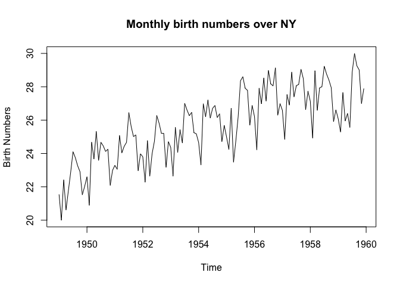

```r
plot(nybirths_ts, ylab = "Birth Numbers", main = "Monthly birth numbers over NY")
```

- For more beautiful plot, you should use the $\texttt{autoplot}$ command from the $\texttt{forecast}$ package:

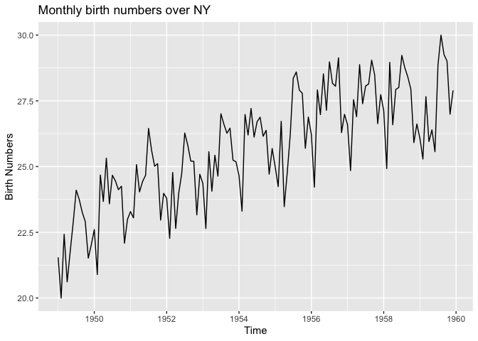

```r
autoplot(nybirths_ts, ylab = "Birth Numbers", main = "Monthly birth numbers over NY")
```

- **What do you see?**
  - Excluding the data at the very left end, there is an overall increasing trend.
  - There is a repetitive variability in the data, i.e., every year there is a spike-ish pattern in the data.
  - This is what we will do next: decompose the time series into it’s components.

## Step 4: Decomposition

- Typically, we discuss $3$ to $4$ components of a time series.
- The long-term pattern in the data is called **trend**.
- The short-term repetitive pattern in the data is called **seasonality**.
- The remaining part in the data is the **residual**/**error**.
- With contextual knowledge, we sometimes may be able to find another component, the **cyclic** component of the time series.
- In $\texttt{R}$, we use the command $\texttt{stl}$, which stands for **Seasonal Decomposition of Time Series by Loess**. You have to mention the periodicity here using $\texttt{s.window}$ here.

```r
nybirths_components = stl(nybirths_ts, s.window = 12)
nybirths_components
```

```
##  Call:
##  stl(x = nybirths_ts, s.window = 12)
##
## Components
##             seasonal    trend    remainder
## Jan 1949 -0.63874098 21.62068  0.566058194
## Feb 1949 -2.05580022 21.73948  0.316318865
## Mar 1949  0.76716306 21.85828 -0.201442982
## Apr 1949 -0.81087504 21.97708 -0.551203444
## May 1949  0.34603624 22.10100 -0.686039203
## Jun 1949  0.10405221 22.22493  0.545020339
## Jul 1949  1.54847960 22.34885  0.206668472
## Aug 1949  1.16933588 22.48255  0.096111911
## Sep 1949  0.66638390 22.61625 -0.020636389
## Oct 1949  0.66980105 22.74995 -0.512753820
## Nov 1949 -1.26629892 22.89407 -0.108773229
## Dec 1949 -0.46993930 23.03819 -0.543252231
## Jan 1950 -0.64988352 23.18231  0.071572606
## Feb 1950 -2.07286853 23.26658 -0.299711559
## Mar 1950  0.76388960 23.35085  0.562261142
## Apr 1950 -0.81706746 23.43512  1.054949026
## May 1950  0.34952115 23.51038  1.460096120
## Jun 1950  0.09321793 23.58565 -0.095864957
## Jul 1950  1.54143488 23.66091 -0.531346211
## Aug 1950  1.17117771 23.72325 -0.440423537
## Sep 1950  0.67769246 23.78558 -0.341272788
## Oct 1950  0.68702204 23.84791 -0.282936863
## Nov 1950 -1.25607033 23.90661 -0.566537946
## Dec 1950 -0.45670534 23.96530 -0.517596385
## Jan 1951 -0.66119029 24.02400 -0.075804892
## Feb 1951 -2.08999025 24.10992  1.029074920
## Mar 1951  0.76067354 24.19584  0.119490983
## Apr 1951 -0.82304742 24.28176  0.578291801
## May 1951  0.35337356 24.33304 -0.256413210
## Jun 1951  0.08292007 24.38432  0.199756261
## Jul 1951  1.53509552 24.43561  0.480296786
## Aug 1951  1.17384274 24.41427  0.029885622
## Sep 1951  0.68994208 24.39294 -0.068877653
## Oct 1951  0.70517754 24.37160  0.033222945
## Nov 1951 -1.24491376 24.34436 -0.135445168
```

[output cut: 82 more lines]

```
## Oct 1958  0.95255919 27.30418 -0.311736289
## Nov 1958 -1.09281235 27.23279 -0.227974644
## Dec 1958 -0.25096045 27.16140 -0.291436434
## Jan 1959 -0.80896421 27.09001 -0.205042576
## Feb 1959 -2.32195866 27.14699  0.460972735
## Mar 1959  0.69782583 27.20397 -0.241790903
## Apr 1959 -0.95869265 27.26094 -0.351251566
## May 1959  0.26815582 27.34755 -1.217701380
## Jun 1959 -0.25348657 27.43415 -1.615660327
## Jul 1959  1.42232218 27.52075 -0.078070425
## Aug 1959  1.33962564 27.61927  1.041104496
## Sep 1959  1.00507232 27.71779  0.538136183
## Oct 1959  0.96378117 27.81631  0.231905709
## Nov 1959 -1.08888360 27.93013  0.150751181
## Dec 1959 -0.24648595 28.04395  0.099534239
```

- Let’s plot the decomposed time series:

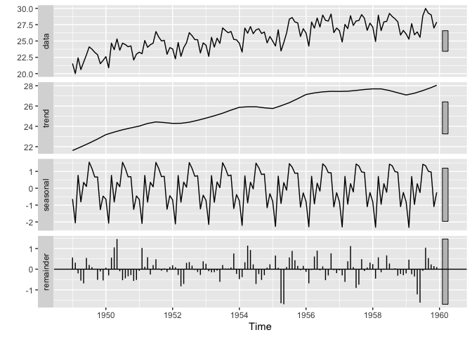

```r
autoplot(nybirths_components)
```

- Check, how the overall trend is increasing, following the overall pattern of the data.
- Look at the repetitive seasonal component that repeats each year in the same fashion.
- If you want to extract different components from this decomposition, you can use the following code:

```r
trend_component = nybirths_components$time.series[, "trend"]
seasonal_component = nybirths_components$time.series[, "seasonal"]
remainder_component = nybirths_components$time.series[, "remainder"]
```

- **What is next?**
  - See that the **seasonal component** repeats it’s behavior each year. This pattern is easier to capture based on the repetitive behavior.
  - **Remainder component** is the residual/error part of the decomposition of a time series; and hence we will not focus on this one.
  - The **trend component** is the most interesting in terms of analysis. See the increasing pattern in the data; which we want to model and analyze below.

## Step 5: Stationarity

- In STL decomposition, the trend component might not be stationary because it reflects long-term changes.
- Statistical models, like AR, MA, ARMA, ARIMA, require a stationary time series, where mean, variance, and autocovariance remain constant over time.
- Therefore, our first job is to check if the series is stationary or not. If it is non-stationary, we need to convert the series into a stationary time series.
- We can use the Augmented Dickey-Fuller (ADF) test to check if a series is stationary.
- The null hypothesis is that the time series is not stationary. The alternate hypothesis of the ADF test is that the series is stationary.
- Let’s do the stationarity test of the trend component using the $\texttt{adf.test(<series_name>)}$ command:

```r
adf_test_result = adf.test(trend_component)
adf_test_result
```

```
##
##  Augmented Dickey-Fuller Test
##
## data:  trend_component
## Dickey-Fuller = -2.7453, Lag order = 5, p-value = 0.2666
## alternative hypothesis: stationary
```

- See that, the $p$ value is really high (greater than typical value of 0.05), which means that our trend component is still non-stationary.
- Our next job is to convert the nonstationary series into a stationary one.

## Step 6: Differencing

- To convert a nonstationary series into a stationary one, one uses differencing.
- For example, if your series is given by $\{y_1, y_2, y_3, \ldots \}$, the first-order differenced series is given by:

$$z_t = y_t - y_{t - 1}$$

- If first-order differencing is not sufficient, you can apply second-order differencing to the already differenced series:

$$z'_t = z_t - z_{t - 1} = (y_t - y_{t
- 1}) - (y_{t-1} - y_{t - 2})$$

- You can continue the same way, but please do not overdifferenciate the series, which is often a problem in Statistics.
- At every step, you should perform a new ADF test to check stationarity using the $\texttt{adf.test(<series_name>)}$ command until the series becomes stationary.
- Let’s try this in $\texttt{R}$:

```r
diff_order_1 = diff(trend_component, lag = 1)
adf.test(diff_order_1)
```

```
##
##  Augmented Dickey-Fuller Test
##
## data:  diff_order_1
## Dickey-Fuller = -3.6814, Lag order = 5, p-value = 0.02868
## alternative hypothesis: stationary
```

- So, your differenced series $\texttt{diff_order_1}$ is now stationary at level $\alpha = 0.05$.
- However, if we are using a level of $0.01$, we need to do the differencing one more time since this differenced series is still not stationary at level $\alpha = 0.01$.
- Let’s do the differencing one more time just to make the series stationary at level $\alpha = 0.01$:

```r
diff_order_2 = diff(diff_order_1, lag = 1)
adf.test(diff_order_2)
```

```
##
##  Augmented Dickey-Fuller Test
##
## data:  diff_order_2
## Dickey-Fuller = -4.3799, Lag order = 5, p-value = 0.01
## alternative hypothesis: stationary
```

- See how low the $p$-value is. Now you can reject your $H_0$ of the ADF test and conclude stationarity.
- Once we’ve achieved stationarity based on the statistical tests, it’s useful to visually confirm this by plotting the differenced series.
- Remember, a stationary series should look like a random scatter around a constant mean and variance, without any clear trends or seasonality.
- First look that the original trend component is visibly following non-stationarity:

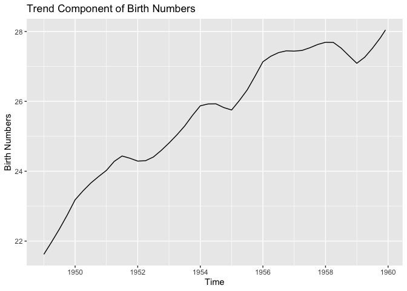

```r
autoplot(trend_component, main = "Trend Component of Birth Numbers", ylab = "Birth Numbers")
```

- Let’s look at the two differenced series that we just created.

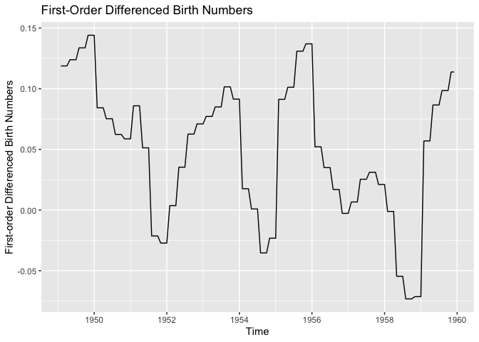

```r
autoplot(diff_order_1, main = "First-Order Differenced Birth Numbers", ylab = "First-order Differenced Birth Numbers")
```

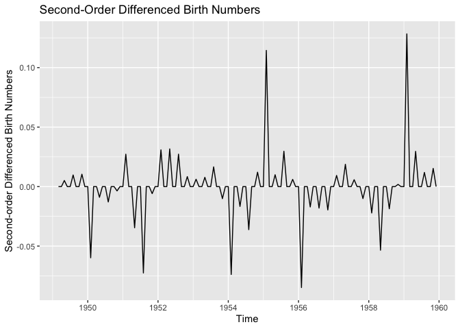

```r
autoplot(diff_order_2, main = "Second-Order Differenced Birth Numbers", ylab = "Second-order Differenced Birth Numbers")
```

- Observe that the differenced series now appears stationary, with fluctuations around a constant mean and relatively stable variance. There is no obvious trend remaining.

## Step 7: ACF and PACF plots

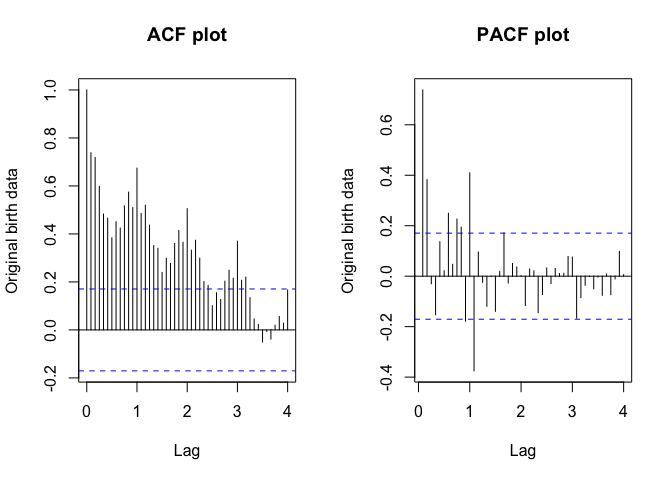

```r
par(mfrow = c(1, 2))
acf(nybirths_ts, lag.max = 48, main = "ACF plot", ylab = "Original birth data")
pacf(nybirths_ts, lag.max = 48,  main = "PACF plot", ylab = "Original birth data")
```

## Step 8: ARIMA Model

Skipping this one to simplify.

## Step 9: Automatic Modeling using $\texttt{auto.arima}$

- $\texttt{R}$ has an inbuilt function, called $\texttt{auto.arima}$, that automatically finds some working values that works for your data.
- You don’t manually need to find the number of AR and MA terms; $\texttt{auto.arima}$ finds those values for you.

```r
automated_birthmodel = auto.arima(nybirths_ts)
automated_birthmodel
```

```
## Series: nybirths_ts
## ARIMA(0,1,3)(2,1,1)[12]
##
## Coefficients:
##           ma1      ma2      ma3     sar1     sar2     sma1
##       -0.1953  -0.3130  -0.2136  -0.5162  -0.4055  -0.6087
## s.e.   0.0932   0.0821   0.0917   0.1203   0.1119   0.1250
##
## sigma^2 = 0.3283:  log likelihood = -110.38
## AIC=234.77   AICc=235.78   BIC=254.22
```

This is a seasonal ARIMA model. It has two components:

1. Non-seasonal component – ARIMA(0,1,3):
- This part is the non-seasonal component of the model.
- The middle coefficient $1$ means that the series has been differnced once (i.e., $y_t - y_{t-1}$) before fitting the AR and MA parts.
- Then, $0$ AR and $3$ MA terms have been used in this component.
2. Seasonal component – (2,1,1)[12]:
- To model the seasonal part, it found a seasonality of 12, which corresponds to monthly data.
- Again, the series got differenced once before fitting the model.
- Finally, $2$ seasonal AR terms and $1$ seasonal moving average (MA) term has been used to fit this part of the data.

## Step 10: Residual Test

### 10A: Plot residuals

- Residuals can be extracted using the $\texttt{residual(<model_name>)}$ command as below:

```r
residuals2 = residuals(automated_birthmodel)
```

- When you plot the residuals, there should be no visible or model-worthy pattern:

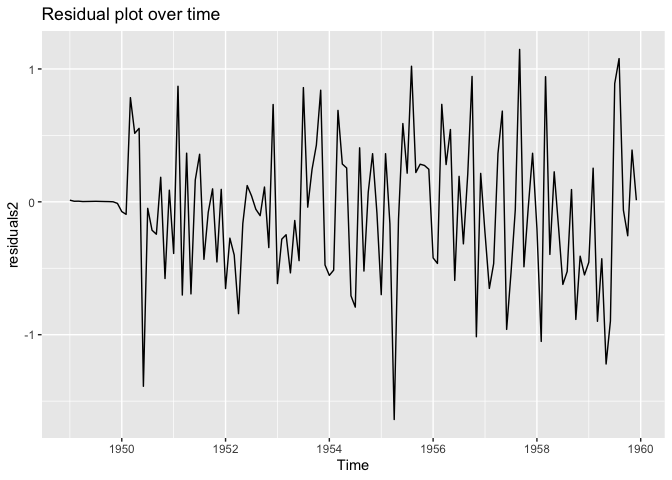

```r
autoplot(residuals2, main = "Residual plot over time")
```

```r
Box.test(residuals2)
```

```
##
##  Box-Pierce test
##
## data:  residuals2
## X-squared = 0.26778, df = 1, p-value = 0.6048
```

## Step 11: Forecasting

- The last step is to forecast the model.
- Just to make it easier, we will use differencing only on the automated model.
- With the automated model, we can use the function $\texttt{forecast(<model_name>, h = <num_periods>)}$ to forecast for $\texttt{<num_periods>}$ number of months.
- Let’s try to forecast for $5$ years or $60$ months in the future.

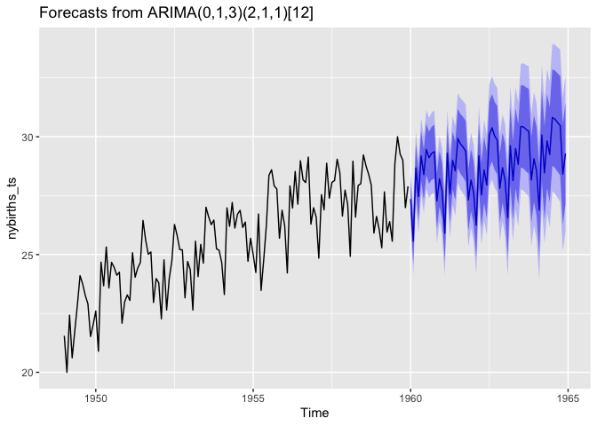

```r
forecasted_series = forecast(automated_birthmodel, h = 60)
autoplot(forecasted_series)
```